# Primary Defeats of House Incumbents, 1946–2024

The election that is supposed to substitute for the one nobody contests

Democracy’s Data

Last updated September 13, 2026 at 10:53a EDT

On the tenth of June 2014, the Majority Leader of the United States House of Representatives lost a primary election — the contest each party holds to choose its nominee for November. It was in Virginia’s seventh district, to an economics professor whose whole campaign had raised about two hundred thousand dollars.[^1] Eric Cantor was the second-ranking Republican in the House and, by most accounts, the next Speaker. No sitting Majority Leader had ever been denied renomination since the office was created in 1899.[^2]

The commentary drew the obvious lesson: incumbents — the members already holding a seat — live in fear of being “primaried,” challenged from inside their own party.[^3] This brief asks the question the lesson skips. How often does a sitting member actually lose a primary?

The number answers a specific argument. About one House race in seven has a single name on the November ballot, and the standard reply is that a safe seat has not removed accountability but moved it upstream, into the summer. Between 2004 and 2022, 3,811 sitting members stood on a primary ballot. 58 of them were refused — 1.52 percent, Cantor among them.

## The test

The main source is the **Federal Election Commission’s** *Federal Elections* series, the compilation the Commission publishes after every two-year election, for 2004 through 2022, downloadable from the [Commission](https://www.fec.gov/introduction-campaign-finance/election-results-and-voting-information/). For every federal candidate it reports the vote in the primary, in any runoff (a second round between the top two, held in states that require a majority), and in the general election, assembled from the states’ official counts. Three properties make it the right source: it is one step from the authoritative record, it is candidate-level, so a losing challenger appears with their votes, and it marks incumbents. The obvious alternative does not exist: the Clerk’s *Statistics of the Congressional Election* contains no primary results in any edition.

The machine-readable workbooks cover only ten elections, and ten elections holding 58 events is not many. So a second series runs alongside. Table 2-7 of **Brookings’** *Vital Statistics on Congress* counts primary defeats for every election from 1946 to 2024, compiled from the *Biographical Directory of the United States Congress* — the official register of everyone who has served — and *CQ Almanac* rather than from returns. A third source, congressional reporter **Greg Giroux’s** hand-kept tracker of members defeated for renomination, is used only as an independent check. And who counts as an incumbent is decided against the roster: Voteview’s membership file, one row per member per Congress since 1789, the record the roster chapter introduces. The FEC’s own incumbent marker turns out to be wrong in both directions.

The test: derive the denial rate from the workbooks, check it against two independent hand-built counts, and then ask whether the primary looks like the site of accountability the argument needs.

## The data

The clean file is `incumbents.csv`: one row per sitting member per election, an *incumbent-cycle*, whether or not anybody ran against them. Its columns, by name: `year`, `stab` and `dnum` for the district, `party`, `unopposed`, `prim_votes` and `prim_share`, `rivals`, `won_nom`, and `denied`. Here is Cantor’s career in it:

| Year | Stab | Dnum | Party | Unopposed | Prim votes | Rivals | Won nom | Denied |
| --- | --- | --- | --- | --- | --- | --- | --- | --- |
| 2004 | VA | 7 | R | TRUE | NA | 0 | TRUE | FALSE |
| 2006 | VA | 7 | R | TRUE | NA | 0 | TRUE | FALSE |
| 2008 | VA | 7 | R | TRUE | NA | 0 | TRUE | FALSE |
| 2010 | VA | 7 | R | TRUE | NA | 0 | TRUE | FALSE |
| 2012 | VA | 7 | R | FALSE | 37369 | 1 | TRUE | FALSE |
| 2014 | VA | 7 | R | FALSE | 28912 | 1 | FALSE | TRUE |

Four cycles where nobody filed against him, one challenger beaten four to one, and 2014. Read that last row. `prim_votes` is 28,912, Cantor’s own vote. `rivals` is 1, so one other name was on the ballot, and the file’s primary total of 65,017 means that rival took 36,105 votes — 55.5 percent to Cantor’s 44.5. `won_nom` is FALSE. And there is no general-election vote for him at all, because he was not on the November ballot. The column this brief is about, `denied`, exists in no source file: the workbooks hold a row per candidate per ballot line, and Cantor’s defeat is recorded nowhere. **It is inferred, from an absence** — a primary vote total, a rival with more votes, and an empty general-election cell. `denied` is true wherever a member stood in a primary and did not come out of it the nominee.

Getting from ballot lines to that table meant deciding, for each member, which contest was actually at stake and whether the incumbent came first. Every rule below was found by a number coming out wrong.

**A blank is not always missing.** Cantor’s empty general-election cell means he was not on the ballot; elsewhere in the same column a blank means the FEC wrote the word `Unopposed` instead of a number. Reading those as missing would have deleted 701 incumbent candidacies from the denominator, the bottom number being divided by.

The result agrees with the people who counted by hand. Across the 10 overlapping elections, Brookings and the Giroux tracker agree with each other exactly, and this derivation matches them in 7 of 10, never off by more than 1. Every miss is this count running short for a named reason: a missing incumbent marker, Louisiana’s blanket ballot, or a nomination made at a party convention — a meeting of party delegates — with no primary to lose.

> **Before you read on, write a number down.** In 2022, 371 House incumbents stood on a primary ballot. **How many of them had even one opponent on that ballot?** Any name at all besides their own. Commit to a count before you look at the figures.

## What it says about democracy

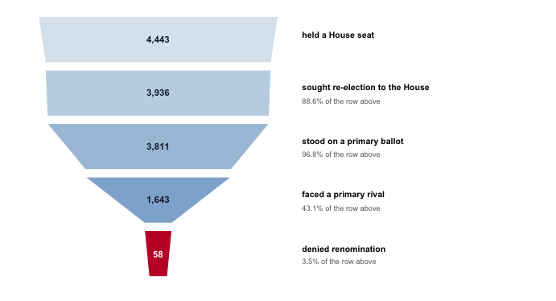

**Figure 1. Every House member-cycle from 2004 to 2022, narrowed one condition at a time.** A funnel, because the argument is about survival at each stage rather than a trend; widths are on a square-root scale so the last band is visible at all. Of the members on a primary ballot, 43.1 percent had at least one rival on it, and 3.5 percent of those were refused the nomination.

58 in 3,811 is 1.52 percent. The Brookings series, over forty elections rather than ten, gives 263 defeats against 15,850 members seeking re-election — 1.66 percent, the same number counted by different people from different documents. **A sitting member of the House who seeks renomination gets it about ninety-eight and a half times in a hundred.** That is the fact the accountability argument has to be made against.[^4]

It would be easy to conclude that nobody bothers. That would be wrong.

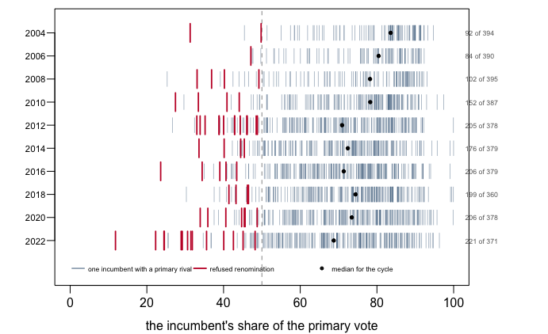

**Figure 2. Every contested incumbent primary from 2004 to 2022, one tick per member.** A barcode rather than a histogram, because the point is the individual members in the left tail. A tick appears only for incumbents who had a rival, at the share of the primary vote they took; red ticks are the 58 members refused renomination.

The count rose from 92 of 394 in 2004, or 23 percent, to 221 of 371 in 2022, or 60 percent. Most readers guess near a quarter. **Being challenged and being beaten have come apart.** Challenges roughly doubled; the denial rate did not.[^5] Incumbents held under sixty percent of their own primary went from 10 to 74, so the pressure is real and measurable. It simply almost never finishes the job.

One caution: the earlier workbooks record fewer minor candidates, so the trend’s direction is better supported than its size.

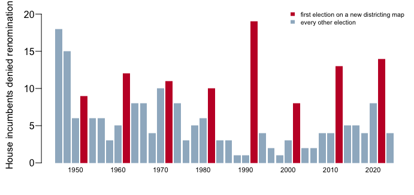

**Figure 3. House incumbents denied renomination at every election from 1946 to 2024, from the Brookings series.** The columns in the accent color are the exceptions with a story: the first election after each ten-year census, when every state has redrawn its House district lines. Those eight average 12.0 denials; the other 32 elections average 5.2, and the tallest column is 1992 at 19.

**The clustering is a redistricting effect, and its mechanism is not what the word “primary” suggests.** A new map does not usually abolish a member’s district; it puts two members into one, and two sitting members in one district produce one primary that one of them must lose. The count doubles without anything changing about how voters feel. Strip those years out and the series is flat and low. There is no long rise in members being turned out by their own voters — the rise a theory of primaries as the new site of accountability would predict.

So where does the fear fit? The literature’s answer: upstream of the ballot. Hall (2019) argues the deeper effect is on *who runs*: if the only plausible candidates in a safe district are ones a primary electorate would accept, the primary chose the field before anybody voted.[^6] Brady, Han and Pope (2007) show that members who drift toward the centre of their district pay a price in primary vote share — a price paid in share, and share is not a seat.[^7]

And there is a mechanical answer this file can support: **anticipation**. A member who expects a serious primary can retire instead, and 49 percent of House departures are members who did not seek re-election at all. No file separates the ones who left because they wanted to from the ones who counted the votes first. **A primary that removes members by frightening them leaves exactly the same trace as no primary at all.**

The finding has two halves: challenge has become ordinary, and defeat has not. Either the fear does the work upstream or nothing does — and these files, which record only what reached a ballot, cannot say which.

## What this brief cannot tell you

**Ten elections is a small window for a rare event.** 58 denials is enough to establish a rate and not enough to model one; the Brookings column extends the rate to forty elections but is not built from returns.

**Three kinds of nomination are invisible here.** A convention, Louisiana’s blanket ballot, and the all-party primaries of California, Washington and, since 2022, Alaska — one ballot for candidates of every party, from which the leaders advance whatever their party — make “denied renomination” either impossible or something else. 1 of the 58 denials happened under a top-two system and are flagged in the data.

**A share of the primary vote is not a measure of danger.** An incumbent held to sixty percent by a strong challenger looks identical to one held there by three unknowns; the file has no candidate quality, no spending, no endorsements. Turnout is missing too: these are shares of whoever voted, and primary electorates are a small, unrepresentative slice of a district.

**And the counterfactual is unobservable.** Whether the primary holds members to account turns on what members do because they fear one, and fear is not a column. This brief can say how often the mechanism fires. It cannot say how often the threat was enough.

## What you should have learned

- A sitting House member who seeks renomination is refused about 1.5 percent of the time: 58 of 3,811 in the FEC years, and 1.66 percent across the Brookings series back to 1946.
- The event this brief counts exists in no source file: `denied` is inferred from an absence — a primary vote, a rival with more, and an empty general-election cell.
- Being challenged and being beaten are different series: the share of incumbents facing any primary opponent roughly doubled between 2004 and 2022, while the denial rate stayed flat.
- The spikes in primary defeats are a redistricting effect: the first election on a new map averages 12.0 denials against 5.2 otherwise, because a new map pairs two members into one district.
- A derived count is only as good as its checks: this one matches two independent hand-built counts in 7 of 10 elections, every miss for a named reason.

## Extensions

None of these is answered above, and every one can be answered from the tables the Sources section hands over.

- `compare.csv` puts three independent counts of the same thing side by side, with `gap_brookings` and `gap_giroux`. Find the years they disagree. Whose count would you use?
- `by_year.csv` has `pct_unopposed` and `pct_contested`. Follow them across the ten cycles. If the general election is uncontested and the primary is unopposed too, who chose the member?
- `denied.csv` lists the incumbents who lost renomination, with `prim_share`. Sort by it. How badly do incumbents lose when they lose?
- `vsoc.csv` splits every year since 1946 into `retired`, `lost_primary`, `lost_general` and `reelected`. Compute the share leaving by each route. Which way out of Congress is most common?

Two stretch ideas point past the spreadsheet. The Giroux tracker covers the current cycle, which the FEC will not report for two more years: download it and see whether this cycle looks like a redistricting year or an ordinary one. And the same workbooks carry the Senate — work out whether senators are denied renomination more or less often than House members.

## Sources

**Data**

- Federal Election Commission, *Federal Elections*, biennial compilations for 2004 through 2022. https://www.fec.gov/introduction-campaign-finance/election-results-and-voting-information/ — retrieved 2026-08-11, 10 workbooks, 22,156 House candidate rows. **The vote totals in this brief are the Commission’s, compiled from the official canvasses of the state election officials.**
- Lewis, J. B., Poole, K., Rosenthal, H., Boche, A., Rudkin, A. and Sonnet, L. *Voteview: Congressional Roll-Call Votes Database*, member file `HSall_members.csv`. https://voteview.com/ — retrieved 2026-08-11, 51,062 rows. Used to decide who was an incumbent.
- Brookings Institution, *Vital Statistics on Congress*, Chapter 2, Table 2-7, edition of April 2026. https://www.brookings.edu/articles/vital-statistics-on-congress/ — 1946 to 2024, compiled from the *Biographical Directory*, *CQ Almanac* and *National Journal*.
- Giroux, G. *Members of Congress Defeated For Renomination, 1966–2026.* https://docs.google.com/spreadsheets/d/1X97S6hUby6PPHAMoEwvAxkAUo8EUwLk8xMosx4hVd8c/ — retrieved 2026-08-11, 288 rows in 32 year-blocks. A hand-kept tracker, cited as an independent check.
- Office of the Clerk, U.S. House of Representatives, *Statistics of the Congressional Election*, 1946 to 2024. https://history.house.gov/Institution/Election-Statistics/Election-Statistics/ — checked and **not** used: it contains no primary results in any edition.

The incumbent table is the one the `retirements` brief describes, built from the same workbooks, which are kept with that brief; the validation results are reproduced in `checks.csv`.

**Academic literature**

- Boatright, R. G. (2013). *Getting Primaried: The Changing Politics of Congressional Primary Challenges.* University of Michigan Press. https://press.umich.edu/Books/G/Getting-Primaried
- Hall, A. B. (2019). *Who Wants to Run? How the Devaluing of Political Office Drives Polarization.* University of Chicago Press. https://press.uchicago.edu/ucp/books/book/chicago/W/bo35612049.html
- Brady, D. W., Han, H. and Pope, J. C. (2007). “Primary Elections and Candidate Ideology: Out of Step with the Primary Electorate?” *Legislative Studies Quarterly* 32(1): 79–105. https://www.jstor.org/stable/40263411
- Hirano, S. and Snyder, J. M. Jr. (2019). *Primary Elections in the United States.* Cambridge University Press. https://www.cambridge.org/core/books/primary-elections-in-the-united-states/C15A9969FFE0323F1751A79B917D8B81
- Ansolabehere, S., Hansen, J. M., Hirano, S. and Snyder, J. M. Jr. (2006). “The Decline of Competition in U.S. Primary Elections, 1908–2004.” *Electoral Studies* 25(2): 271–291. https://doi.org/10.1016/j.electstud.2006.02.001
- Mayhew, D. R. (1974). *Congress: The Electoral Connection.* Yale University Press.

**The data itself**

Every figure above is drawn from these tables. They are plain CSV, they open in a spreadsheet, and they are yours to take further.

`by_year.csv`, `compare.csv`, `denied.csv`, `giroux.csv`, `incumbents.csv`, `vsoc.csv`, `exits_by_year.csv`

One more file is not data about the subject – it is how this chapter checked its own work: `checks.csv`, the arithmetic verified before anything was drawn.

[^1]: Brat’s campaign reported raising $206,663 to Cantor’s $5,447,290: NBC News, “A Dramatic Defeat: Cantor v. Brat, By the Numbers,” 11 June 2014, https://www.nbcnews.com/politics/congress/dramatic-defeat-cantor-v-brat-numbers-n128761. The vote itself is on the Virginia pages of the Commission’s *Federal Elections 2014*, https://www.fec.gov/resources/cms-content/documents/federalelections2014.pdf.
[^2]: The House’s own list of its Majority Leaders begins with Sereno Payne in 1899: Office of the Historian, U.S. House of Representatives, “Majority Leaders of the House,” https://history.house.gov/People/Office/Majority-Leaders/.
[^3]: The word, and whether the fear is warranted, is the subject of Robert G. Boatright, *Getting Primaried: The Changing Politics of Congressional Primary Challenges* (Ann Arbor: University of Michigan Press, 2013), https://press.umich.edu/Books/G/Getting-Primaried, which finds that challenges to incumbents had not become much more frequent over four decades, only more noticed.
[^4]: The same rate, carried back to the primary’s introduction a century ago, is in Shigeo Hirano and James M. Snyder Jr., *Primary Elections in the United States* (Cambridge: Cambridge University Press, 2019), https://www.cambridge.org/core/books/primary-elections-in-the-united-states/C15A9969FFE0323F1751A79B917D8B81.
[^5]: Over a century rather than a decade the trend runs the other way: Stephen Ansolabehere, John Mark Hansen, Shigeo Hirano and James M. Snyder Jr., “The Decline of Competition in U.S. Primary Elections, 1908–2004,” *Electoral Studies* 25, no. 2 (2006): 271–291, https://doi.org/10.1016/j.electstud.2006.02.001, find House primaries far less contested after 1950 than before.
[^6]: Andrew B. Hall, *Who Wants to Run? How the Devaluing of Political Office Drives Polarization* (Chicago: University of Chicago Press, 2019), https://press.uchicago.edu/ucp/books/book/chicago/W/bo35612049.html.
[^7]: David W. Brady, Hahrie Han and Jeremy C. Pope, “Primary Elections and Candidate Ideology: Out of Step with the Primary Electorate?” *Legislative Studies Quarterly* 32, no. 1 (2007): 79–105, https://www.jstor.org/stable/40263411.